# Lab 10 - Trees, Bagging, RF, Boosting, XGBoost

# Learning goals

- Perform classification and regression with tree-based methods in R
- Recognize that tree-based methods are capable of capturing non-linearities by splitting multiple times on the same variables
- Compare the performance of classification trees, bagging, random forests, and boosting for predicting heart disease based on the `heart` data.

# Lab description

For this lab we will be working with the `heart` dataset that you can download from [here](https://github.com/JSC370/JSC370-2025/blob/main/data/heart.csv)

# Deliverables

Questions 1-5 answered, pdf or html output uploaded to Quercus

### Setup packages

You should install and load `rpart` (trees), `randomForest` (random forest), `gbm` (gradient boosting) and `xgboost` (extreme gradient boosting).

```r
install.packages(c("rpart", "rpart.plot", "randomForest", "gbm", "xgboost"))
```

### Load packages and data

```r
library(tidyverse)
library(rpart)
library(rpart.plot)
library(randomForest)
library(gbm)
library(xgboost)
library(caret)

heart <- read_csv("https://raw.githubusercontent.com/JSC370/JSC370-2025/refs/heads/main/data/heart/heart.csv")

heart <- heart %>% mutate(
    AHD = 1 * (AHD == "Yes"),
    ChestPain = factor(ChestPain),
    Thal = factor(Thal)
  )

heart <- heart %>% mutate(AHD = factor(AHD))

head(heart)
```

```
## # A tibble: 6 × 14
##     Age   Sex ChestPain    RestBP  Chol   Fbs RestECG MaxHR ExAng Oldpeak Slope
##   <dbl> <dbl> <fct>         <dbl> <dbl> <dbl>   <dbl> <dbl> <dbl>   <dbl> <dbl>
## 1    63     1 typical         145   233     1       2   150     0     2.3     3
## 2    67     1 asymptomatic    160   286     0       2   108     1     1.5     2
## 3    67     1 asymptomatic    120   229     0       2   129     1     2.6     2
## 4    37     1 nonanginal      130   250     0       0   187     0     3.5     3
## 5    41     0 nontypical      130   204     0       2   172     0     1.4     1
## 6    56     1 nontypical      120   236     0       0   178     0     0.8     1
## # ℹ 3 more variables: Ca <dbl>, Thal <fct>, AHD <fct>
```

## Question 1: Trees

- Split the `heart` data into training and testing (70-30%)

```r
set.seed(123)  # Ensure reproducibility
train_index <- createDataPartition(heart$AHD, p = 0.7, list = FALSE)
heart_train <- heart[train_index, ]
heart_test <- heart[-train_index, ]
```

- Fit a classification tree using rpart, plot the full tree. We are trying to predict AHD. Set minsplit = 10, minbucket = 3, and do 10 cross validations.

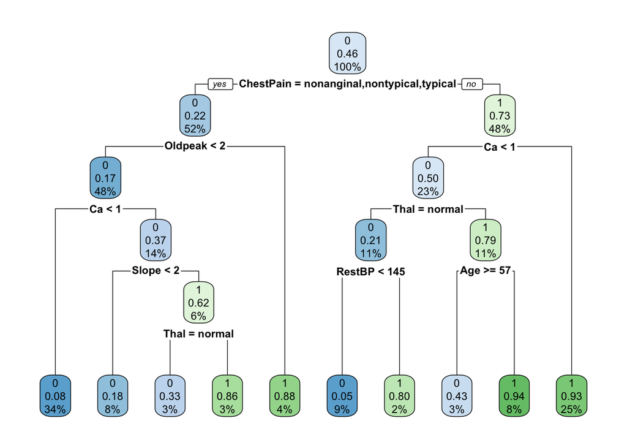

```r
heart_tree <- rpart(
  AHD ~ .,
  data = heart_train,
  method = "class",
  control = rpart.control(minsplit = 10, minbucket = 3, cp = 0.01, xval = 10)
)

# Plot the decision tree
rpart.plot(heart_tree)
```

- Plot the complexity parameter table for an rpart fit and find the optimal cp

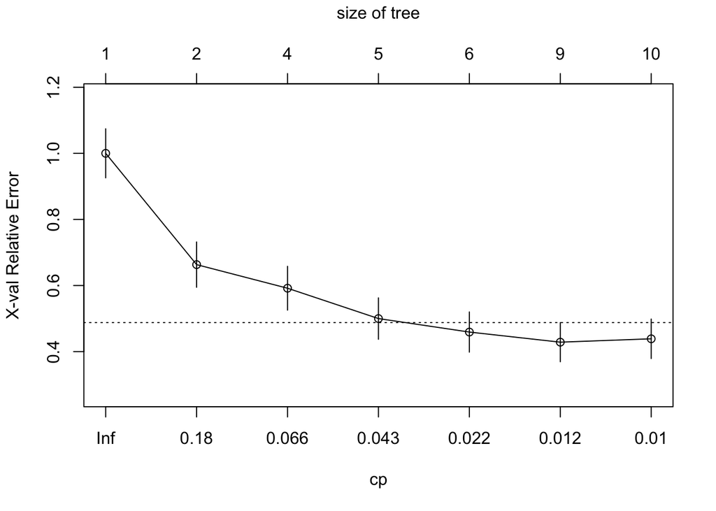

```r
plotcp(heart_tree)
```

```r
printcp(heart_tree)
```

```
##
## Classification tree:
## rpart(formula = AHD ~ ., data = heart_train, method = "class",
##     control = rpart.control(minsplit = 10, minbucket = 3, cp = 0.01,
##         xval = 10))
##
## Variables actually used in tree construction:
## [1] Age       Ca        ChestPain Oldpeak   RestBP    Slope     Thal
##
## Root node error: 98/213 = 0.46009
##
## n= 213
##
##         CP nsplit rel error  xerror     xstd
## 1 0.469388      0   1.00000 1.00000 0.074224
## 2 0.071429      1   0.53061 0.66327 0.068576
## 3 0.061224      3   0.38776 0.59184 0.066292
## 4 0.030612      4   0.32653 0.50000 0.062676
## 5 0.015306      5   0.29592 0.45918 0.060792
## 6 0.010204      8   0.24490 0.42857 0.059253
## 7 0.010000      9   0.23469 0.43878 0.059778
```

```r
optimal_cp <- heart_tree$cptable[which.min(heart_tree$cptable[, "xerror"]), "CP"]
optimal_cp
```

```
## [1] 0.01020408
```

- Prune the tree

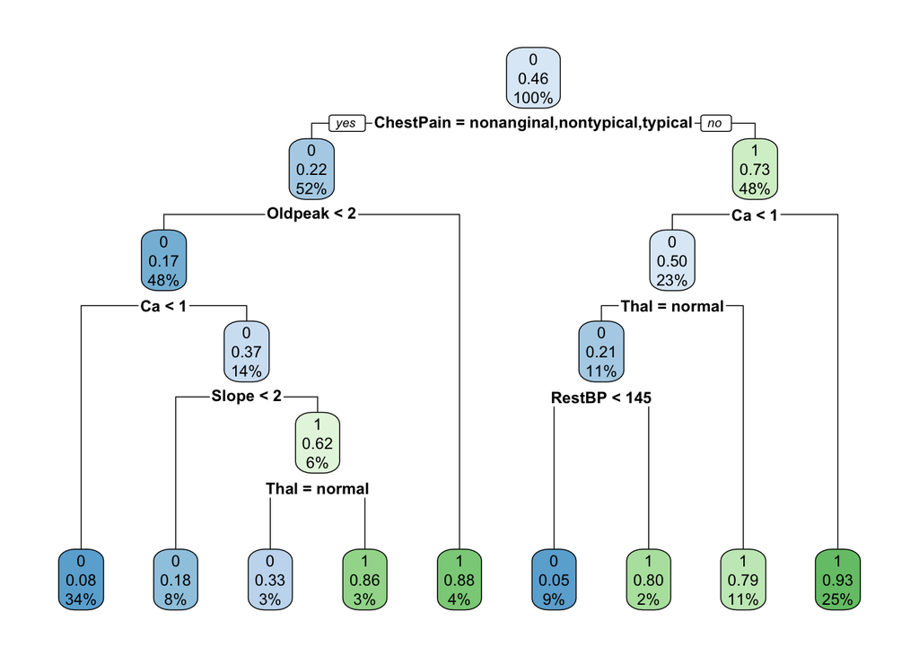

```r
heart_tree_prune <- prune(heart_tree, cp = optimal_cp)

rpart.plot(heart_tree_prune)
```

- Compute the test misclassification error

```r
heart_pred <- predict(heart_tree_prune, heart_test, type = "class")

conf_matrix <- table(heart_test$AHD, heart_pred)
test_error <- 1 - sum(diag(conf_matrix)) / sum(conf_matrix)
test_error
```

```
## [1] 0.2111111
```

- Fit the tree with the optimal complexity parameter to the full data (training + testing)

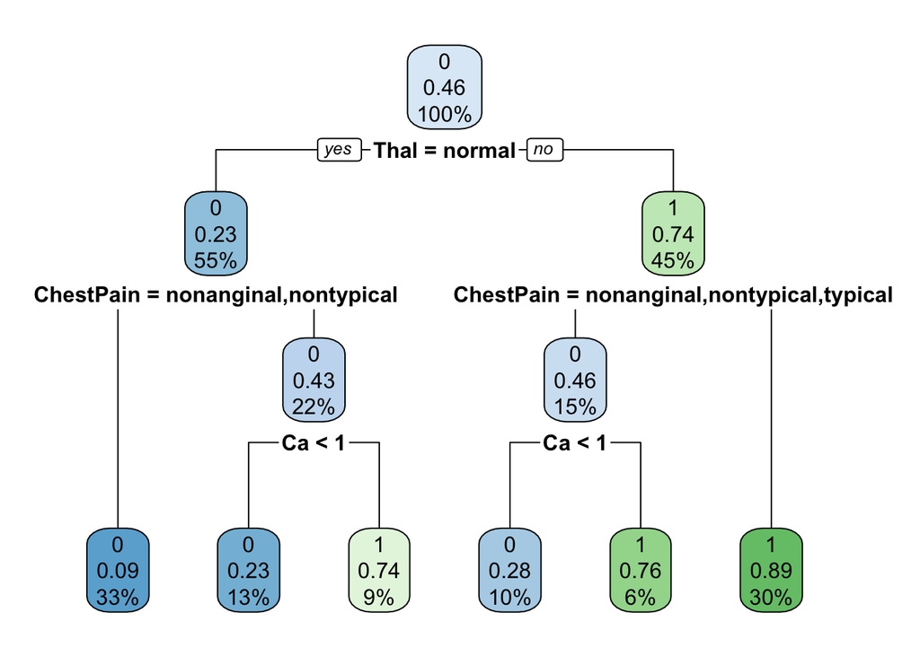

```r
heart_tree_full <- rpart(
  AHD ~ .,
  data = heart,
  method = "class",
  control = rpart.control(cp = optimal_cp)
)

rpart.plot(heart_tree_full)
```

- Find the Out of Bag (OOB) error for tree

```r
set.seed(123)
heart <- na.omit(heart)

cv_tree <- train(
  AHD ~ .,
  data = heart,
  method = "rpart",
  trControl = trainControl(method = "cv", number = 10), # 10-fold CV
  tuneGrid = data.frame(cp = optimal_cp)
)

oob_error <- 1 - max(cv_tree$results$Accuracy)
oob_error
```

```
## [1] 0.1954023
```

## Question 2: Bagging, Random Forest

- Compare the performance of classification trees (above), bagging, random forests for predicting heart disease based on the `heart` data.
- Use the training and testing sets from above. Train each of the models on the training data and extract the cross-validation (or out-of-bag error for bagging and Random forest).
- For bagging use `randomForest` with `mtry` equal to the number of features (all other parameters at their default values). Generate the variable importance plot using `varImpPlot` and extract variable importance from the `randomForest` fitted object using the `importance` function.

```r
num_features <- ncol(heart_train) - 1

set.seed(123)
heart_train <- na.omit(heart_train)
heart_bag <- randomForest(
  AHD ~ .,
  data = heart_train,
  mtry = num_features,
  importance = TRUE
)

oob_error_bag <- heart_bag$err.rate[nrow(heart_bag$err.rate), 1]
oob_error_bag
```

```
##       OOB
## 0.1666667
```

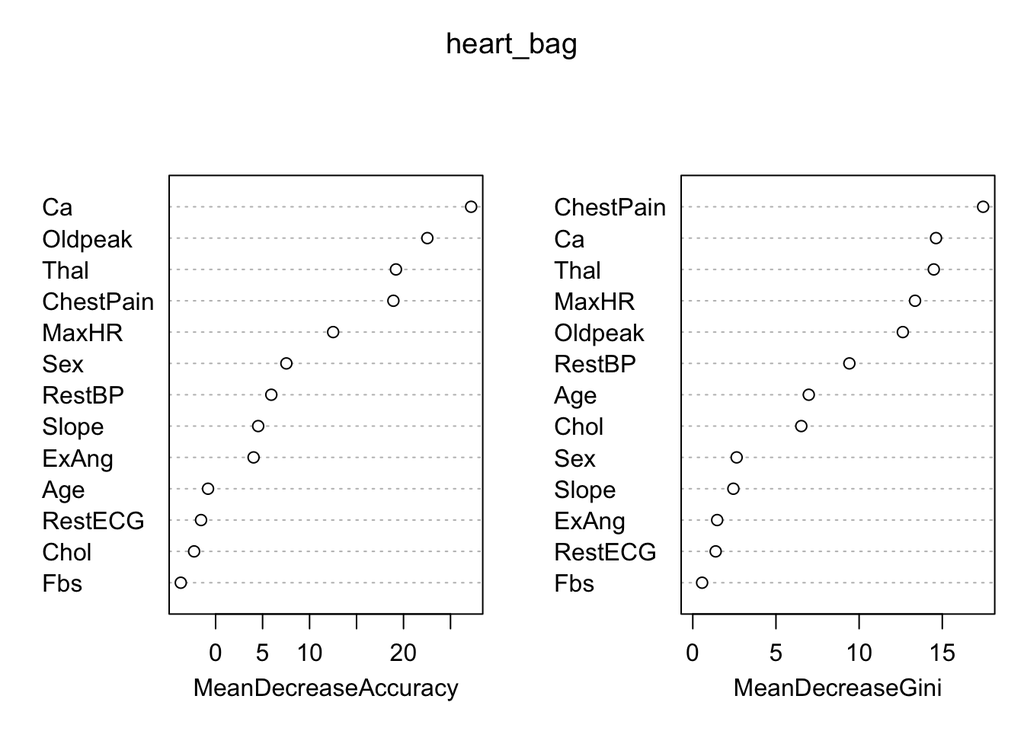

```r
varImpPlot(heart_bag)
```

```r
importance(heart_bag)
```

```
##                    0         1 MeanDecreaseAccuracy MeanDecreaseGini
## Age       -2.2549188  1.450352           -0.8054396        6.9732542
## Sex        6.1030443  5.010856            7.5312371        2.6365306
## ChestPain 10.3573329 16.462979           18.9201479       17.4549605
## RestBP     2.8017888  6.218654            5.9282878        9.4140954
## Chol       0.6850130 -4.585654           -2.2885474        6.5230657
## Fbs       -1.5595198 -3.618533           -3.7052118        0.5598005
## RestECG   -0.2096681 -2.212770           -1.5484705        1.3758614
## MaxHR      8.5593159  7.836757           12.5082510       13.3618166
## ExAng      2.1260399  3.422653            4.0405124        1.4661237
## Oldpeak   20.1800474 12.684576           22.5344598       12.6263099
## Slope      0.9481076  5.448962            4.5335090        2.4393540
## Ca        22.1866473 18.089010           27.1945615       14.6231400
## Thal      13.7645931 14.565445           19.1948186       14.4882588
```

- For random forests use `randomForest` with the default parameters. Generate the variable importance plot using `varImpPlot` and extract variable importance from the `randomForest` fitted object using the `importance` function.

```r
set.seed(123)
heart_rf <- randomForest(
  AHD ~ .,
  data = heart_train,
  importance = TRUE
)

oob_error_rf <- heart_rf$err.rate[nrow(heart_rf$err.rate), 1]
oob_error_rf
```

```
##       OOB
## 0.1714286
```

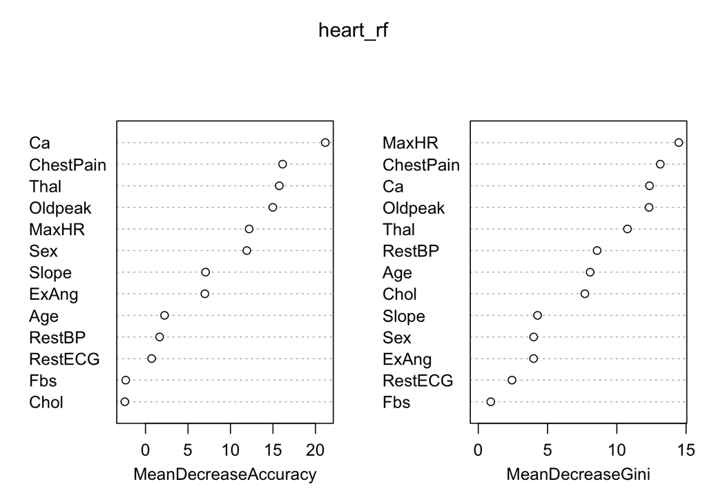

```r
varImpPlot(heart_rf)
```

```r
importance(heart_rf)
```

```
##                    0           1 MeanDecreaseAccuracy MeanDecreaseGini
## Age        2.0919858  1.24145534            2.2379490        8.0733141
## Sex       10.4485404  6.78869098           11.9201041        3.9977735
## ChestPain  9.5077994 14.43160938           16.1365539       13.1382109
## RestBP     0.3041973  2.15906784            1.6576275        8.5761830
## Chol       0.3280782 -3.92358753           -2.4346492        7.6934585
## Fbs       -0.4688111 -2.72579129           -2.3269973        0.9000232
## RestECG    0.9122726  0.07472895            0.7188874        2.4301047
## MaxHR      7.6303558  9.70371896           12.1963083       14.4730980
## ExAng      2.4524169  7.22052446            6.9858218        3.9898422
## Oldpeak    9.5180257 12.28160563           14.9827891       12.3242701
## Slope      1.5480843  8.44148537            7.0695321        4.2788091
## Ca        18.8495593 14.19959369           21.1567012       12.3587596
## Thal      12.7598816 12.07228695           15.7435458       10.7670461
```

# Question 3: Boosting

- For boosting use `gbm` with `cv.folds=5` to perform 5-fold cross-validation, and set `class.stratify.cv` to `AHD` (heart disease outcome) so that cross-validation is performed stratifying by `AHD`. Plot the cross-validation error as a function of the boosting iteration/trees (the `$cv.error` component of the object returned by `gbm`) and determine whether additional boosting iterations are warranted. If so, run additional iterations with `gbm.more` (use the R help to check its syntax). Choose the optimal number of iterations. Use the `summary.gbm` function to generate the variable importance plot and extract variable importance/influence (`summary.gbm` does both). Generate 1D and 2D marginal plots with `gbm.plot` to assess the effect of the top three variables and their 2-way interactions.

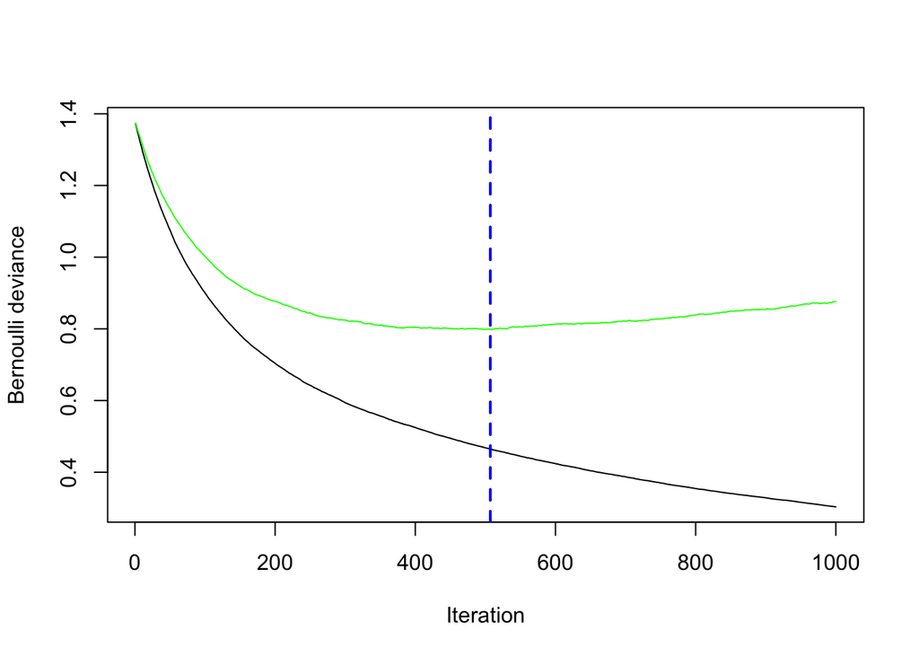

```
## [1] 507
```

```r
heart_train_numeric <- heart_train %>% mutate(AHD = as.integer(AHD) - 1)
heart_train_numeric <- na.omit(heart_train_numeric)
set.seed(123)
heart_boost <- gbm(
  AHD ~ .,
  data = heart_train_numeric,
  distribution = "bernoulli",
  n.trees = 1000,
  interaction.depth = 3,
  shrinkage = 0.01,
  cv.folds = 5,
  class.stratify.cv = TRUE,
  n.cores = NULL,
  verbose = FALSE
)

gbm.perf(heart_boost, method = "cv")
```

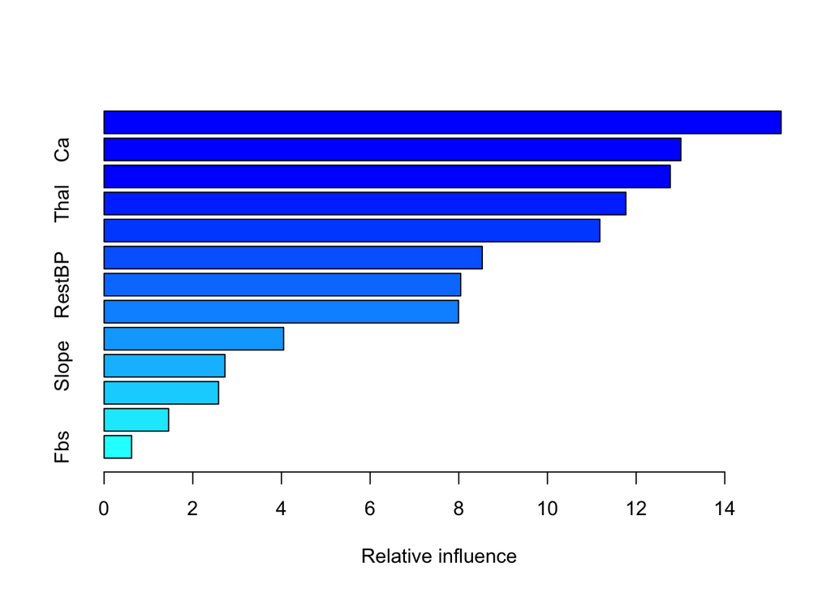

```
##                 var    rel.inf
## ChestPain ChestPain 15.2707056
## Ca               Ca 13.0102665
## Oldpeak     Oldpeak 12.7701381
## Thal           Thal 11.7693003
## MaxHR         MaxHR 11.1818061
## Chol           Chol  8.5292202
## RestBP       RestBP  8.0435779
## Age             Age  7.9944688
## Sex             Sex  4.0490659
## Slope         Slope  2.7251657
## RestECG     RestECG  2.5815801
## ExAng         ExAng  1.4548794
## Fbs             Fbs  0.6198254
```

```r
heart_boost <- gbm.more(heart_boost, n.new.trees = 500)

summary(heart_boost)
```

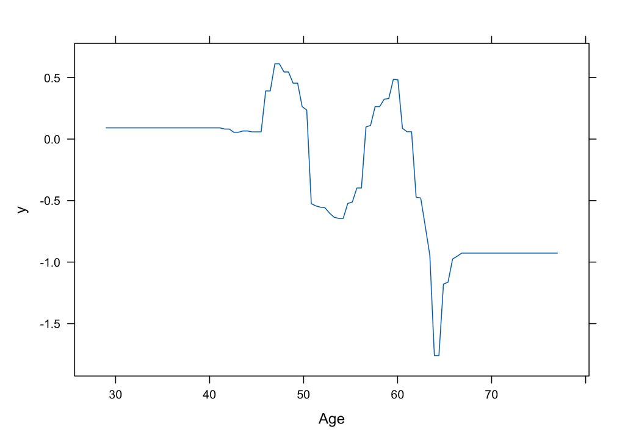

```r
par(mfrow = c(2, 2))
plot(heart_boost, i.var = 1)
```

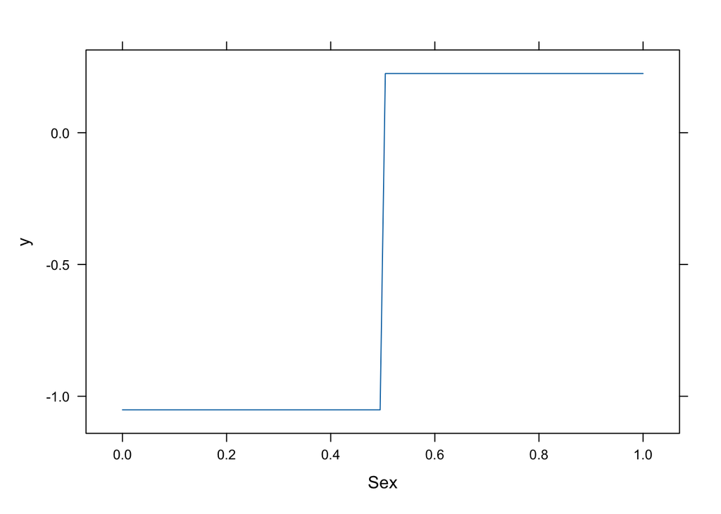

```r
plot(heart_boost, i.var = 2)
```

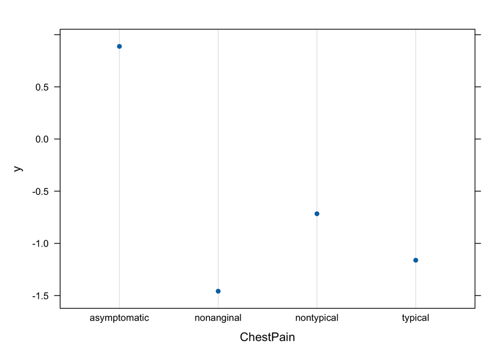

```r
plot(heart_boost, i.var = 3)
```

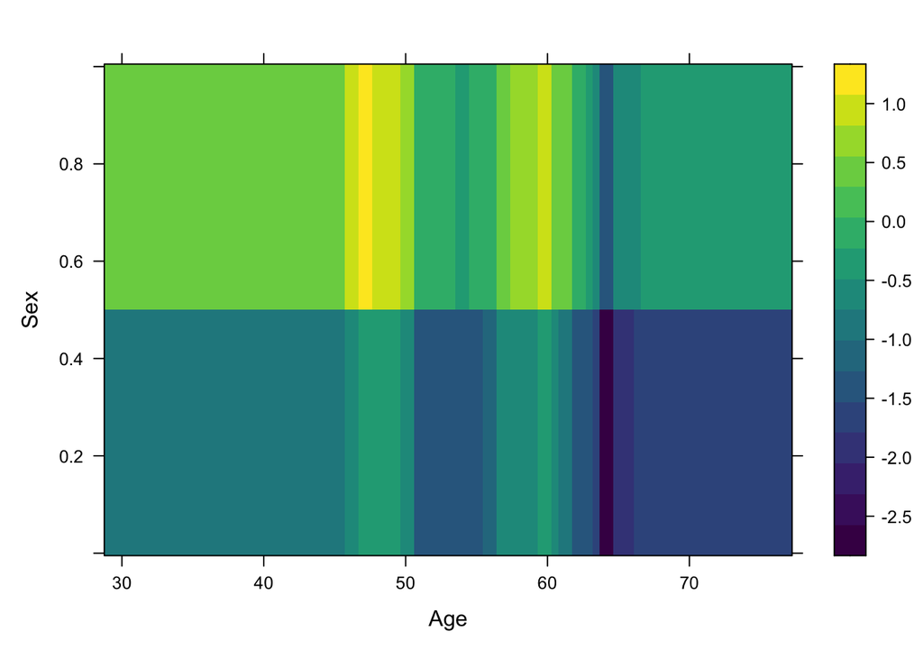

```r
plot(heart_boost, i.var = c(1, 2))
```

## Question 4: Gradient Boosting

Evaluate the effect of critical boosting parameters (number of boosting iterations, shrinkage/learning rate, and tree depth/interaction). In `gbm` the number of iterations is controlled by `n.trees` (default is 100), the shrinkage/learning rate is controlled by `shrinkage` (default is 0.001), and interaction depth by `interaction.depth` (default is 1).

Note, boosting can overfit if the number of trees is too large. The shrinkage parameter controls the rate at which the boosting learns. Very small $\lambda$ can require using a very large number of trees to achieve good performance. Finally, interaction depth controls the interaction order of the boosted model. A value of 1 implies an additive model, a value of 2 implies a model with up to 2-way interactions, etc. the default is 1.

- Set the seed and train a boosting classification with `gbm` using 10-fold cross-validation (`cv.folds=10`) on the training data with `n.trees = 5000`, `shrinkage = 0.001`, and `interaction.depth =1`. Plot the cross-validation errors as a function of the boosting iteration and calculate the test MSE.

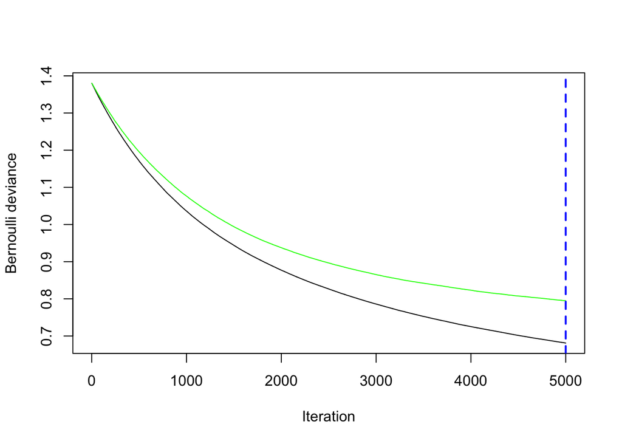

```
## [1] 5000
```

```r
set.seed(301)
heart_boost_1 <- gbm(
  AHD ~ .,
  data = heart_train_numeric,
  distribution = "bernoulli",
  n.trees = 5000,
  interaction.depth = 1,
  shrinkage = 0.001,
  cv.folds = 10,
  class.stratify.cv = TRUE,
  n.cores = NULL,
  verbose = FALSE
)

gbm.perf(heart_boost_1, method = "cv")
```

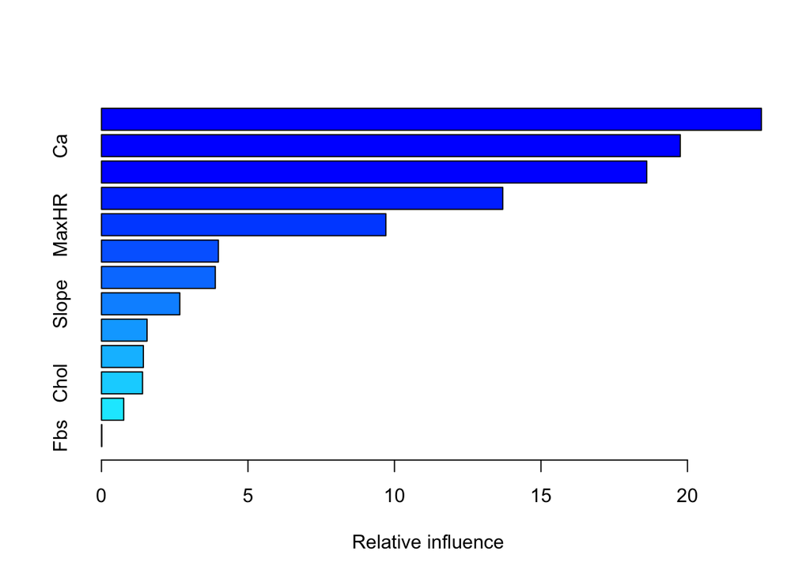

```
##                 var     rel.inf
## ChestPain ChestPain 22.52379940
## Ca               Ca 19.75461408
## Thal           Thal 18.61102131
## Oldpeak     Oldpeak 13.69710501
## MaxHR         MaxHR  9.70717048
## RestBP       RestBP  3.99042611
## Sex             Sex  3.88532833
## Slope         Slope  2.67360046
## ExAng         ExAng  1.55508136
## RestECG     RestECG  1.42930908
## Chol           Chol  1.40137850
## Age             Age  0.75921701
## Fbs             Fbs  0.01194887
```

```r
summary(heart_boost_1)
```

```r
best_iter_1 <- gbm.perf(heart_boost_1, method = "cv", plot.it = FALSE)
yhat_boost_1 <- predict(heart_boost_1, heart_test, n.trees = best_iter_1, type = "response")

yhat_boost_class_1 <- ifelse(yhat_boost_1 > 0.5, 1, 0)

mse_1 <- mean((yhat_boost_class_1 - heart_test$AHD)^2)
mse_1
```

```
## [1] NA
```

- Repeat the above using the same seed and `n.trees=5000` with the following 3 additional combination of parameters: a) `shrinkage = 0.001`, `interaction.depth = 2`; b) `shrinkage = 0.01`, `interaction.depth = 1`; c) `shrinkage = 0.01`, `interaction.depth = 2`.

```r
set.seed(301)
heart_boost_2 <- gbm(AHD ~ .,
                     data = heart_train_numeric, distribution = "bernoulli",
                      n.trees = 5000, interaction.depth = 2,
                     shrinkage = 0.001,
                      cv.folds = 10,
                     class.stratify.cv = TRUE, verbose = FALSE)

set.seed(301)
heart_boost_3 <- gbm(AHD ~ ., data = heart_train_numeric, distribution = "bernoulli", n.trees = 5000, interaction.depth = 1, shrinkage = 0.01,
                      cv.folds = 10, class.stratify.cv = TRUE,
                     verbose = FALSE)

set.seed(301)
heart_boost_4 <- gbm(AHD ~ ., data = heart_train_numeric, distribution = "bernoulli", n.trees = 5000, interaction.depth = 2, shrinkage = 0.01,
                      cv.folds = 10, class.stratify.cv = TRUE,
                      verbose = FALSE)


# Function to compute MSE
compute_mse <- function(model, test_data) {
  best_iter <- gbm.perf(model, method = "cv", plot.it = FALSE)
  preds <- predict(model, test_data, n.trees = best_iter, type = "response")
  preds_class <- ifelse(preds > 0.5, 1, 0)
  mean((preds_class - test_data$AHD)^2)
}

# Compute MSE for all models
mse_2 <- compute_mse(heart_boost_2, heart_test)
mse_3 <- compute_mse(heart_boost_3, heart_test)
mse_4 <- compute_mse(heart_boost_4, heart_test)
# Compare results
mse_results <- data.frame(
  Model = c("Shrinkage=0.001, Depth=1", "Shrinkage=0.001, Depth=2",
            "Shrinkage=0.01, Depth=1", "Shrinkage=0.01, Depth=2"),
  MSE = c(mse_1, mse_2, mse_3, mse_4)
)

print(mse_results)
```

```
##                      Model MSE
## 1 Shrinkage=0.001, Depth=1  NA
## 2 Shrinkage=0.001, Depth=2  NA
## 3  Shrinkage=0.01, Depth=1  NA
## 4  Shrinkage=0.01, Depth=2  NA
```

## Question 5: Extreme Gradient Boosting

Train a XGBoost model with `xgboost` and perform a grid search for tuning the number of trees and the maximum depth of the tree. Also perform 10-fold cross-validation and determine the variable importance. Finally, compute the test MSE.

Tuning parameters - max_depth: tree depth, larger makes model more complex and potentially overfit - nrounds: number of boosting iterations - eta: learning rate (shrinkage) - gamma: minimum loss reduction required to make a further partition on a leaf node of the tree. The larger gamma is, the more conservative the algorithm will be (simpler model) - min_child_weight: controls the minimum number of samples in a leaf node before further splitting - colsample_bytree: controls the fraction of features (variables) used to build each tree. Default is 1 which is all features

```r
library(caret)
dummies <- dummyVars(AHD ~ ., data = heart_train)
heart_train_transformed <- predict(dummies, newdata = heart_train)
heart_train_transformed <- as.data.frame(heart_train_transformed)

heart_train_transformed$AHD <- heart_train$AHD
train_matrix <- as.matrix(heart_train_transformed %>% select(-AHD))
train_labels <- as.factor(heart_train_transformed$AHD)

train_control <- trainControl(method = "cv", number = 10, search = "grid")
heart_test <- heart_test %>%
  mutate(
    ChestPain = as.factor(ChestPain),
    Thal = as.factor(Thal)
  )

heart_test_transformed <- predict(dummies, newdata = heart_test)
heart_test_transformed <- as.data.frame(heart_test_transformed)

heart_test_transformed$AHD <- heart_test$AHD
test_matrix <- as.matrix(heart_test_transformed %>% select(-AHD))
test_labels <- as.factor(heart_test_transformed$AHD)

heart_train <- heart_train %>%
  mutate(
    ChestPain = as.factor(ChestPain),
    Thal = as.factor(Thal)
  )
tune_grid <- expand.grid(
  max_depth = c(1, 3, 5, 7),
  nrounds = (1:10) * 50,
  eta = c(0.01, 0.1, 0.3),
  gamma = 0,
  subsample = 1,
  min_child_weight = 1,
  colsample_bytree = 0.6
)

heart_xgb <- caret::train(
  x = train_matrix,
  y = train_labels,
  method = "xgbTree",
  trControl = train_control,
  tuneGrid = tune_grid,
  metric = "Accuracy"  # For classification
)
```

[output not shown]

[output cut: 1025 more lines]

[output not shown]

```r
print(heart_xgb$bestTune)
```

```
##    nrounds max_depth eta gamma colsample_bytree min_child_weight subsample
## 51      50         3 0.1     0              0.6                1         1
```

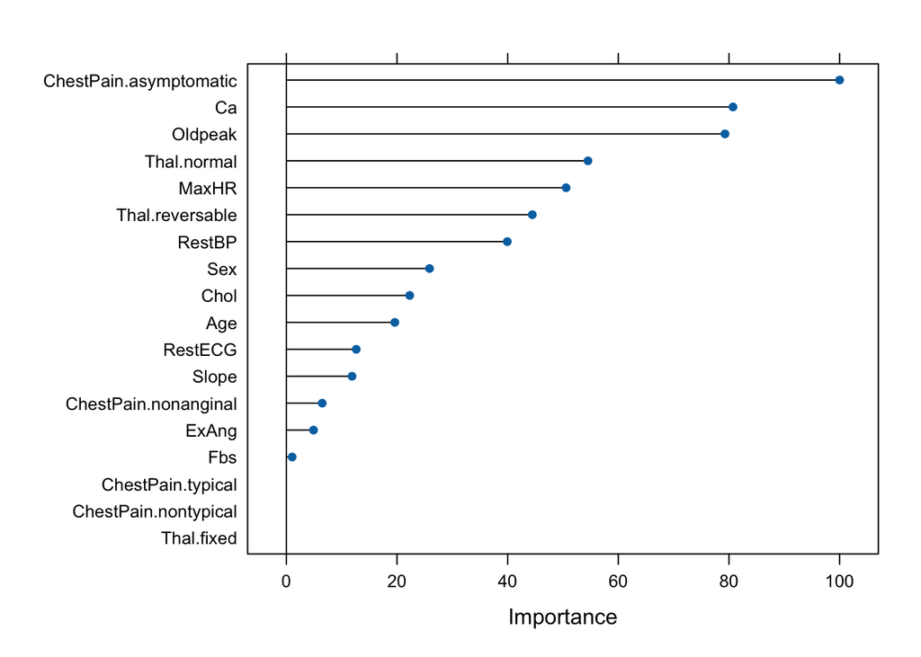

```r
varimp <- varImp(heart_xgb)
plot(varimp)
```

```r
yhat_xgb <- predict(heart_xgb, newdata = test_matrix)

confusionMatrix(yhat_xgb, test_labels)
```

```
## Confusion Matrix and Statistics
##
##           Reference
## Prediction  0  1
##          0 42  9
##          1  7 32
##
##                Accuracy : 0.8222
##                  95% CI : (0.7274, 0.8948)
##     No Information Rate : 0.5444
##     P-Value [Acc > NIR] : 2.84e-08
##
##                   Kappa : 0.6402
##
##  Mcnemar's Test P-Value : 0.8026
##
##             Sensitivity : 0.8571
##             Specificity : 0.7805
##          Pos Pred Value : 0.8235
##          Neg Pred Value : 0.8205
##              Prevalence : 0.5444
##          Detection Rate : 0.4667
##    Detection Prevalence : 0.5667
##       Balanced Accuracy : 0.8188
##
##        'Positive' Class : 0
##
```